# Data from Kaggle and the Five Thirty Eight Websites

## Rafael Djamous

www.rafaeldjamous.github.io

# Overview

In the project, I focused on the sources that provided us with interesting data as well as those that would easily be extracted. I finally chose to settle with data from Kaggle and the Five Thirty Eight websites. The extraction methods for the data from these sites is different so let us look at them one at a time.

### Five Thirty Eight website

The data obtained from this website was the National Hockey League (NHL) data. It contains data for the team ratings, match ratings and scores between different teams among others. The website provides a link the csv file; we therefore read the file directly using the read_csv method of Pandas. Our main interest was to find out the highest rated games in NHL. We did this by ranking sorting the dataframe based on the 'game_overall_rating' column and taking the first 10 samples of the sorted data using the ‘head’ method of a Pandas dataframe.

We then plotted a bar graph to show the overall game ratings using matplotlib library. Below is the output.

[figure not shown]

Further, we were able to note from the data, that the higher the game quality and the game importance ratings, the higher the game overall rating.

### Kaggle

The data obtained from Kaggle is the World happiness data. It contains data such as the Overall rank, Country or region, Score, GDP per capita, Social support, Healthy life expectancy, Freedom to make life choices, Generosity and Perceptions of corruption.

Extraction of data from Kaggle is quite different when compared to the Four Thirty Eight website. We make use of the opendatasets library to download the dataset from Kaggle. This prompts us to provide the details like the Kaggle username and the key, we are obtained in a json file downloaded from Kaggle under the ‘Account’ option. After provideng these details, the dataset is downloaded and exracted to our working directory. From here, we can then read the csv file using the read_csv method of Pandas.

Our main interest here was to find the correlation between the happiness score and the GDP per capita. To investigate this, we made a scatterplot using seaborn and this included a regression line. The output graph showed that the two are directly proportional in most parts of the world. Below is the output graph:

[figure not shown]

### Challenges Faced

The main challenge we faced was in the extraction of data from Kaggle since we did not know that a json file from Kaggle was required so as to download the data.

# Code

```python
import pandas as pd
import matplotlib.pyplot as plt
import seaborn as sns
```

### Data from FiveThirtyEight website

```python
# Data from FiveThirtyEight website
# We want to investigate the top 10 games that have got the highest overall ratings
nhl_url = 'https://projects.fivethirtyeight.com/nhl-api/nhl_elo_latest.csv'
nhl_df = pd.read_csv(nhl_url)
nhl_df.head()
```

|  | season | date | playoff | neutral | status | ot | home_team | away_team | home_team_abbr | away_team_abbr | ... | overtime_prob | home_team_expected_points | away_team_expected_points | home_team_score | away_team_score | home_team_postgame_rating | away_team_postgame_rating | game_quality_rating | game_importance_rating | game_overall_rating |
| --- | --- | --- | --- | --- | --- | --- | --- | --- | --- | --- | --- | --- | --- | --- | --- | --- | --- | --- | --- | --- | --- |
| 0 | 2023 | 2022-10-07 | 0 | 1 | post | NaN | Nashville Predators | San Jose Sharks | NSH | SJS | ... | 0.234345 | 1.258314 | 0.976030 | 4.0 | 1.0 | 1510.044255 | 1446.464381 | 15 | 41 | 28 |
| 1 | 2023 | 2022-10-08 | 0 | 1 | post | NaN | San Jose Sharks | Nashville Predators | SJS | NSH | ... | 0.233053 | 0.956634 | 1.276419 | 2.0 | 3.0 | 1444.546428 | 1511.962208 | 15 | 43 | 29 |
| 2 | 2023 | 2022-10-11 | 0 | 0 | post | NaN | New York Rangers | Tampa Bay Lightning | NYR | TBL | ... | 0.238935 | 1.193826 | 1.045109 | 3.0 | 1.0 | 1554.002969 | 1567.724755 | 97 | 24 | 60 |
| 3 | 2023 | 2022-10-11 | 0 | 0 | post | NaN | Los Angeles Kings | Vegas Golden Knights | LAK | VEG | ... | 0.240107 | 1.177400 | 1.062707 | 3.0 | 4.0 | 1498.528556 | 1531.054886 | 60 | 77 | 68 |
| 4 | 2023 | 2022-10-12 | 0 | 0 | post | NaN | Washington Capitals | Boston Bruins | WSH | BOS | ... | 0.239010 | 1.192780 | 1.046230 | 2.0 | 5.0 | 1521.075399 | 1552.242965 | 84 | 54 | 69 |

5 rows × 24 columns

```python
#Sorting the games in descending order based on'game_overall_rating'
sorted_nhl_df = nhl_df.sort_values(by=['game_overall_rating'], ascending=False)
sorted_nhl_df.head()
```

|  | season | date | playoff | neutral | status | ot | home_team | away_team | home_team_abbr | away_team_abbr | ... | overtime_prob | home_team_expected_points | away_team_expected_points | home_team_score | away_team_score | home_team_postgame_rating | away_team_postgame_rating | game_quality_rating | game_importance_rating | game_overall_rating |
| --- | --- | --- | --- | --- | --- | --- | --- | --- | --- | --- | --- | --- | --- | --- | --- | --- | --- | --- | --- | --- | --- |
| 819 | 2023 | 2023-02-08 | 0 | 0 | pre | NaN | Dallas Stars | Minnesota Wild | DAL | MIN | ... | 0.238057 | 1.206162 | 1.031894 | NaN | NaN | NaN | NaN | 75 | 94 | 84 |
| 392 | 2023 | 2022-12-04 | 0 | 0 | pre | NaN | Dallas Stars | Minnesota Wild | DAL | MIN | ... | 0.238057 | 1.206162 | 1.031894 | NaN | NaN | NaN | NaN | 75 | 91 | 83 |
| 1257 | 2023 | 2023-04-08 | 0 | 0 | pre | NaN | Minnesota Wild | St. Louis Blues | MIN | STL | ... | 0.238333 | 1.202284 | 1.036049 | NaN | NaN | NaN | NaN | 90 | 75 | 82 |
| 1021 | 2023 | 2023-03-08 | 0 | 0 | pre | NaN | Winnipeg Jets | Minnesota Wild | WPG | MIN | ... | 0.240026 | 1.178533 | 1.061493 | NaN | NaN | NaN | NaN | 68 | 97 | 82 |
| 770 | 2023 | 2023-01-26 | 0 | 0 | pre | NaN | Washington Capitals | Pittsburgh Penguins | WSH | PIT | ... | 0.239031 | 1.192483 | 1.046548 | NaN | NaN | NaN | NaN | 80 | 84 | 82 |

5 rows × 24 columns

```python
team_pairs = pd.DataFrame() #We create a dataframe that will show us only the home and away team pairs plus the ratings
team_pairs['home_team'] = sorted_nhl_df['home_team']
team_pairs['away_team'] = sorted_nhl_df['away_team']
team_pairs['overall_rating'] = sorted_nhl_df['game_overall_rating']
team_pairs = team_pairs.reset_index().head(10)
del team_pairs['index']
team_pairs.head(10)
```

|  | home_team | away_team | overall_rating |
| --- | --- | --- | --- |
| 0 | Dallas Stars | Minnesota Wild | 84 |
| 1 | Dallas Stars | Minnesota Wild | 83 |
| 2 | Minnesota Wild | St. Louis Blues | 82 |
| 3 | Winnipeg Jets | Minnesota Wild | 82 |
| 4 | Washington Capitals | Pittsburgh Penguins | 82 |
| 5 | New York Islanders | Tampa Bay Lightning | 82 |
| 6 | Minnesota Wild | Dallas Stars | 82 |
| 7 | Washington Capitals | New York Rangers | 81 |
| 8 | New York Islanders | Toronto Maple Leafs | 80 |
| 9 | Minnesota Wild | Dallas Stars | 80 |

```python
#Lets create a plot to visualize this
values = team_pairs['overall_rating'].values#The rating values
#lets now generate the team pairs
labels = []
for i in range(0,10):
    home_team = sorted_nhl_df['home_team'].loc[i]
    away_team = sorted_nhl_df['away_team'].loc[i]
    pair = home_team + ' VS ' + away_team
    labels.append(pair)
```

[figure not shown]

```python
fig = plt.figure(figsize = (10, 5))

y_pos = range(len(labels))
plt.bar(y_pos, values)
plt.xticks(y_pos, labels, rotation=90)
plt.xlabel('Teams')
plt.ylabel('Overall_Rating')
plt.title('Overall Game Ratings')
plt.savefig('OverallGameRatings')
plt.show()
```

### Kaggle Dataset

- The aim is to find out the correlation between hapiness score and the GDP per capita in various countries

```python
! pip install opendatasets
```

```python
import opendatasets as od
```

```python
dataset = 'https://www.kaggle.com/datasets/unsdsn/world-happiness'
```

```python
od.download(dataset)
```

```
Please provide your Kaggle credentials to download this dataset. Learn more: http://bit.ly/kaggle-creds
Your Kaggle username: rafaeldjamous
Your Kaggle Key: ··········
Downloading world-happiness.zip to ./world-happiness
```

```python
df = pd.read_csv('./world-happiness/2019.csv')
```

```python
df.head()
```

|  | Overall rank | Country or region | Score | GDP per capita | Social support | Healthy life expectancy | Freedom to make life choices | Generosity | Perceptions of corruption |
| --- | --- | --- | --- | --- | --- | --- | --- | --- | --- |
| 0 | 1 | Finland | 7.769 | 1.340 | 1.587 | 0.986 | 0.596 | 0.153 | 0.393 |
| 1 | 2 | Denmark | 7.600 | 1.383 | 1.573 | 0.996 | 0.592 | 0.252 | 0.410 |
| 2 | 3 | Norway | 7.554 | 1.488 | 1.582 | 1.028 | 0.603 | 0.271 | 0.341 |
| 3 | 4 | Iceland | 7.494 | 1.380 | 1.624 | 1.026 | 0.591 | 0.354 | 0.118 |
| 4 | 5 | Netherlands | 7.488 | 1.396 | 1.522 | 0.999 | 0.557 | 0.322 | 0.298 |

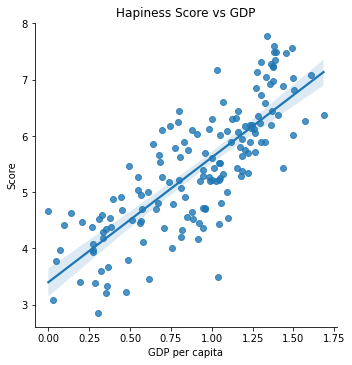

```python
sns.lmplot(x='GDP per capita', y='Score',data=df,fit_reg=True)
plt.title('Hapiness Score vs GDP')
plt.savefig('HapinessScoreVsGDP')
plt.show()
```

```python
%%shell
jupyter nbconvert --to html /content.ipynb
```

```python
from google.colab import drive
drive.mount('/content/drive')
```